# Benjamin_ModelBuilding

Benjamin Huynh

2025-11-24

```r
data <- read.csv("Combined_Teams_2022-2024.csv")
head(data)
```

```
##                          Tm X.Bat BatAge  R.G   PA   AB R_Bat H_Bats X2B_Bats
## 1 Arizona Diamondbacks 2022    57   26.5 4.33 6027 5351   702   1232      262
## 2       Atlanta Braves 2022    53   27.5 4.87 6082 5509   789   1394      298
## 3    Baltimore Orioles 2022    58   27.0 4.16 6049 5429   674   1281      275
## 4       Boston Red Sox 2022    54   28.8 4.54 6144 5539   735   1427      352
## 5         Chicago Cubs 2022    64   27.9 4.06 6072 5425   657   1293      265
## 6    Chicago White Sox 2022    44   29.3 4.23 6123 5611   686   1435      272
##   X3B_Bat HR_Bat RBI  SB CS BB_Bat SO_Bat    BA   OBP   SLG   OPS OPS.   TB GDP
## 1      24    173 658 104 29    531   1341 0.230 0.304 0.385 0.689   95 2061  97
## 2      11    243 753  87 31    470   1498 0.253 0.317 0.443 0.761  109 2443 103
## 3      25    171 639  95 31    476   1390 0.236 0.305 0.390 0.695   99 2119  95
## 4      12    155 704  52 20    478   1373 0.258 0.321 0.409 0.731  102 2268 131
## 5      31    159 620 111 37    507   1448 0.238 0.311 0.387 0.698   94 2097 130
## 6       9    149 654  58 10    388   1269 0.256 0.310 0.387 0.698   97 2172 127
##   HBP_Bat SH SF IBB_Bat LOB_Bat X.Fld RA.G_P DefEff CG_F   Inn   Ch   PO    A
```

[output cut: 34 more lines]

#Step 1

```r
set.seed(123)

n <- nrow(data)
train_index <- sample(1:n, size = 0.7 * n)
train_data <- data[train_index, ]
test_data  <- data[-train_index, ]

y_var <- "W"


model <- lm(formula = W ~ OPS + ERA + FIP + HR_Bat + Rdrs, data = train_data)

summary(model)
```

```
##
## Call:
## lm(formula = W ~ OPS + ERA + FIP + HR_Bat + Rdrs, data = train_data)
##
## Residuals:
##     Min      1Q  Median      3Q     Max
## -8.8739 -2.7112  0.3021  2.7023  7.7840
##
## Coefficients:
##              Estimate Std. Error t value Pr(>|t|)
## (Intercept)  -9.71790   15.53797  -0.625   0.5342
## OPS         234.29701   23.58345   9.935 5.79e-14 ***
## ERA         -13.60010    1.99841  -6.805 7.25e-09 ***
## FIP          -3.03004    2.63106  -1.152   0.2544
## HR_Bat       -0.04970    0.02582  -1.924   0.0594 .
## Rdrs          0.08094    0.06171   1.312   0.1950
## ---
## Signif. codes:  0 '***' 0.001 '**' 0.01 '*' 0.05 '.' 0.1 ' ' 1
##
## Residual standard error: 4.033 on 56 degrees of freedom
## Multiple R-squared:  0.919,  Adjusted R-squared:  0.9118
## F-statistic: 127.1 on 5 and 56 DF,  p-value: < 2.2e-16
```

```r
y_var <- "W"

numeric_cols <- names(train_data)[sapply(train_data, is.numeric)]
numeric_cols <- numeric_cols[-1]                  # drop first column
numeric_cols <- setdiff(numeric_cols, y_var)     # drop response variable

correlations <- train_data %>%
  select(all_of(numeric_cols)) %>%
  summarise(across(everything(),
                   ~ cor(.x, train_data[[y_var]], use = "complete.obs"))) %>%
  pivot_longer(everything(), names_to = "Variable", values_to = "Correlation") %>%
  arrange(desc(abs(Correlation)))
correlations
```

```
## # A tibble: 84 × 2
##    Variable Correlation
##    <chr>          <dbl>
##  1 Non.P          0.828
##  2 WHIP          -0.807
##  3 RA.G_P        -0.806
##  4 R_P           -0.806
##  5 OPS.           0.796
##  6 SO.W           0.793
##  7 ERA           -0.788
##  8 ERA.           0.780
##  9 ER            -0.778
## 10 R.G            0.777
## # ℹ 74 more rows
```

#Step 2

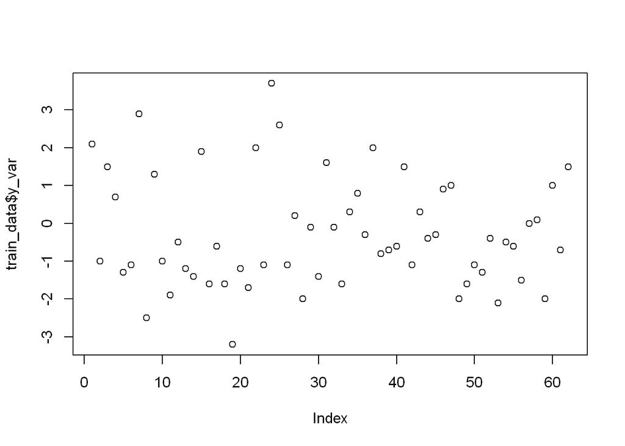

```r
plot(train_data$DH, train_data$y_var)
```

```r
train_data$DH_centered <- train_data$DH - mean(train_data$DH)
train_data$DH_c2 <- train_data$DH_c^2
model1 <- lm(
  W ~ OPS + ERA + FIP + HR_Bat + Rdrs + DH_centered + DH_c2,
  data = train_data
)
summary(model1)
```

```
##
## Call:
## lm(formula = W ~ OPS + ERA + FIP + HR_Bat + Rdrs + DH_centered +
##     DH_c2, data = train_data)
##
## Residuals:
##    Min     1Q Median     3Q    Max
## -8.107 -2.877  0.274  2.282  7.405
##
## Coefficients:
##              Estimate Std. Error t value Pr(>|t|)
## (Intercept)  -7.53543   15.57428  -0.484   0.6305
## OPS         222.71270   24.82118   8.973 2.74e-12 ***
## ERA         -13.23468    1.97368  -6.706 1.24e-08 ***
## FIP          -2.52320    2.58081  -0.978   0.3326
## HR_Bat       -0.03012    0.02651  -1.136   0.2610
## Rdrs          0.07398    0.06127   1.207   0.2325
## DH_centered   0.17683    0.62555   0.283   0.7785
## DH_c2        -0.50346    0.24845  -2.026   0.0477 *
## ---
## Signif. codes:  0 '***' 0.001 '**' 0.01 '*' 0.05 '.' 0.1 ' ' 1
##
## Residual standard error: 3.904 on 54 degrees of freedom
## Multiple R-squared:  0.9268, Adjusted R-squared:  0.9173
## F-statistic:  97.7 on 7 and 54 DF,  p-value: < 2.2e-16
```

```r
vif(model1)
```

```
##         OPS         ERA         FIP      HR_Bat        Rdrs DH_centered
##    3.377814    4.896575    4.777277    3.057372    1.133406    3.313943
##       DH_c2
##    1.982867
```

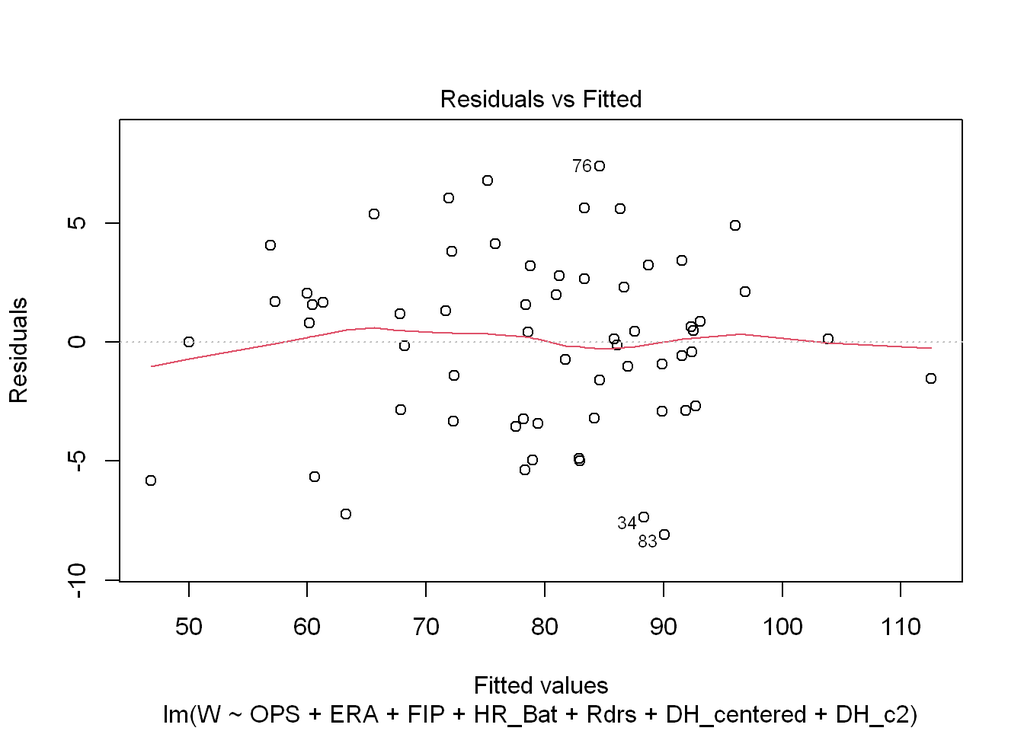

```r
plot(model1, which = 1)
```

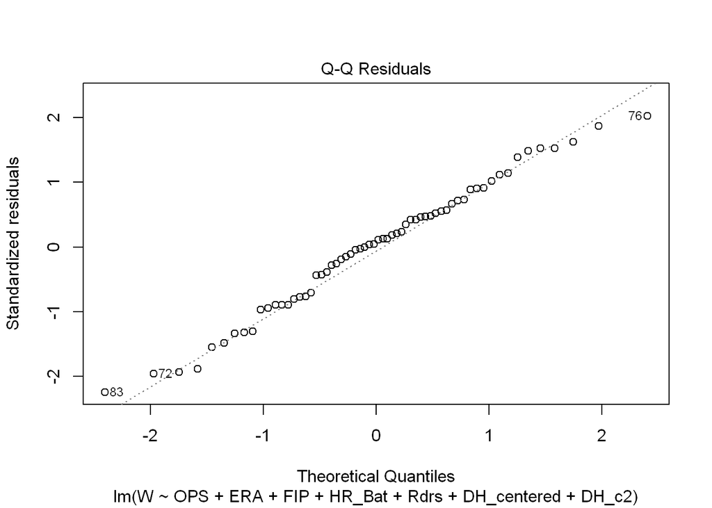

```r
plot(model1, which = 2)
```

```r
hist(residuals(model),
     main = "Histogram of Residuals for Model 1",
     xlab = "Residuals")
```

[output not shown]

```r
#install.packages("lmtest")
library(lmtest)
dwtest(model1)
```

```
##
##  Durbin-Watson test
##
## data:  model1
## DW = 1.7908, p-value = 0.2051
## alternative hypothesis: true autocorrelation is greater than 0
```

```r
vif(model)
```

```
##      OPS      ERA      FIP   HR_Bat     Rdrs
## 2.856769 4.703026 4.651554 2.717532 1.076986
```

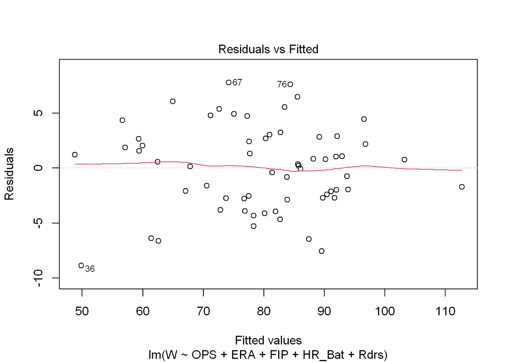

```r
plot(model, which = 1)
```

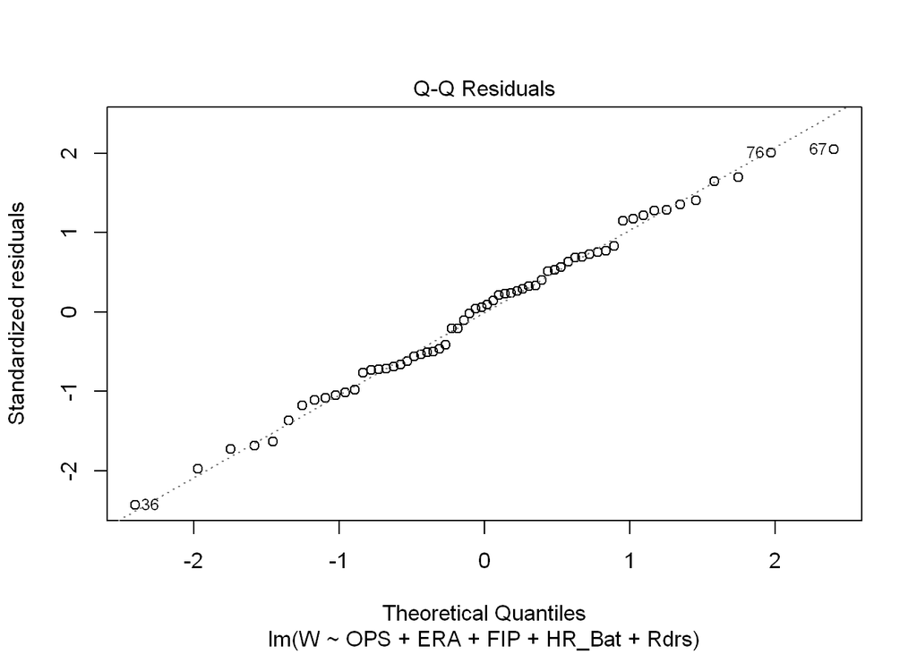

```r
plot(model, which = 2)
```

```r
hist(residuals(model),
     main = "Histogram of Residuals for Model 1",
     xlab = "Residuals")
```

[output not shown]

```r
#install.packages("lmtest")
library(lmtest)
dwtest(model)
```

```
##
##  Durbin-Watson test
##
## data:  model
## DW = 1.7267, p-value = 0.1447
## alternative hypothesis: true autocorrelation is greater than 0
```

The curvature slightly improved the model. The p-value for the polynomia is less than 0.05 indicating statistical significance. The assumptions remained relatively the same, looking at constant variance, nomality, and indepedence. The vifs are relatively the same also, the polynomial model is slightly higher which is expected with more predictors. R^2 adjusted is slightly higher in the model with the curvature which leads me to the conclusion that the polynomial model is a slight improvement over the first model.

#step3

```r
#model1 <- lm(W ~ OPS + ERA + FIP + HR_Bat + Rdrs + DH_centered + DH_c2, data = train_data)

model2 <- lm(W ~ OPS*HR_Bat + OPS + HR_Bat + ERA + FIP + Rdrs + DH_centered + DH_c2, data = train_data)
summary(model2)
```

```
##
## Call:
## lm(formula = W ~ OPS * HR_Bat + OPS + HR_Bat + ERA + FIP + Rdrs +
##     DH_centered + DH_c2, data = train_data)
##
## Residuals:
##     Min      1Q  Median      3Q     Max
## -8.5055 -2.8505  0.3392  2.3795  7.4653
##
## Coefficients:
##              Estimate Std. Error t value Pr(>|t|)
## (Intercept) -29.64669   44.97486  -0.659  0.51263
## OPS         253.09451   63.08099   4.012  0.00019 ***
## HR_Bat        0.08265    0.21664   0.382  0.70433
## ERA         -13.15635    1.99266  -6.602 1.97e-08 ***
## FIP          -2.65803    2.61099  -1.018  0.31329
## Rdrs          0.06259    0.06539   0.957  0.34284
## DH_centered   0.09955    0.64679   0.154  0.87826
## DH_c2        -0.47912    0.25440  -1.883  0.06515 .
## OPS:HR_Bat   -0.15210    0.28997  -0.525  0.60209
## ---
## Signif. codes:  0 '***' 0.001 '**' 0.01 '*' 0.05 '.' 0.1 ' ' 1
##
## Residual standard error: 3.93 on 53 degrees of freedom
## Multiple R-squared:  0.9272, Adjusted R-squared:  0.9162
## F-statistic: 84.38 on 8 and 53 DF,  p-value: < 2.2e-16
```

```r
vif(model2)
```

```
## there are higher-order terms (interactions) in this model
## consider setting type = 'predictor'; see ?vif
```

```
##         OPS      HR_Bat         ERA         FIP        Rdrs DH_centered
##   21.523785  201.386456    4.924234    4.824031    1.273746    3.495266
##       DH_c2  OPS:HR_Bat
##    2.051104  303.835408
```

The interaction term is not statistically significant. The p value is greater than 0.05 indicating that there is no evidence that the interaction between hr bats and ops is statistically significant. It also has a lower adjusted r-squared value than the reduced model meaning that the second model is being punished for including the interaction term. In theory, the interaction between OPS and HR_bats does increase interpretability. In the context of baseball, OPS or on base percentage + slugging percentage does matter for teams that also hit more home runs.

#Step 4

```r
model1 <- lm(W ~ OPS + ERA + HR_Bat + Rdrs + DH_centered + DH_c2, data = train_data)
summary(model1)
```

```
##
## Call:
## lm(formula = W ~ OPS + ERA + HR_Bat + Rdrs + DH_centered + DH_c2,
##     data = train_data)
##
## Residuals:
##     Min      1Q  Median      3Q     Max
## -8.5954 -2.4860  0.3339  2.6255  6.4911
##
## Coefficients:
##              Estimate Std. Error t value Pr(>|t|)
## (Intercept) -10.81121   15.20349  -0.711   0.4800
## OPS         222.08315   24.80287   8.954  2.5e-12 ***
## ERA         -14.80939    1.14024 -12.988  < 2e-16 ***
## HR_Bat       -0.03073    0.02649  -1.160   0.2512
## Rdrs          0.08128    0.06079   1.337   0.1867
## DH_centered   0.26782    0.61834   0.433   0.6666
## DH_c2        -0.53849    0.24575  -2.191   0.0327 *
## ---
## Signif. codes:  0 '***' 0.001 '**' 0.01 '*' 0.05 '.' 0.1 ' ' 1
##
## Residual standard error: 3.902 on 55 degrees of freedom
## Multiple R-squared:  0.9255, Adjusted R-squared:  0.9174
## F-statistic: 113.9 on 6 and 55 DF,  p-value: < 2.2e-16
```

The current model, No there is not need for variable screening. If we were to expand the model though to all possible second terms yes there would be too many variables and there would be a lot of multicollinearity.

#Step 5

```r
library(MASS)
```

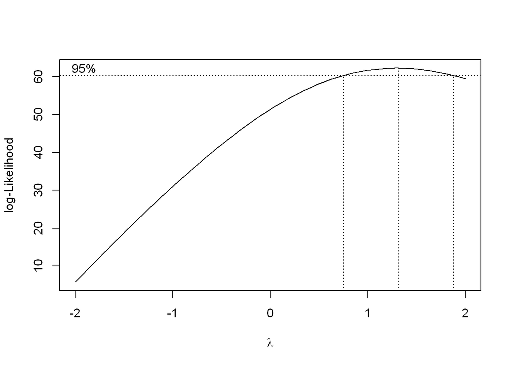

```r
boxcox(model1)
```

Since the model shows a lamda of around 1 for most of the 95% confidence interval there is no need of a transformation of the y variable.

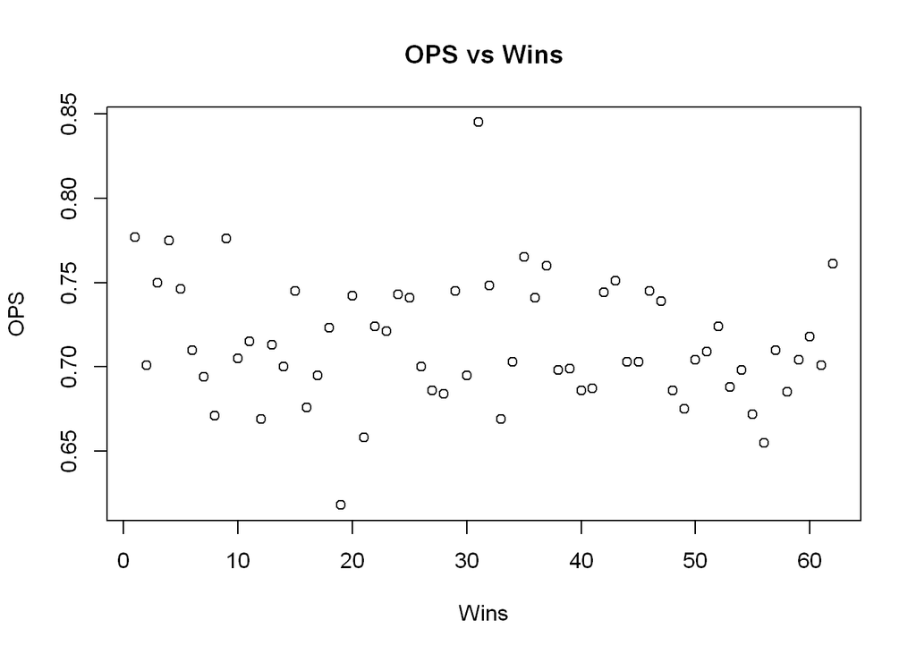

```r
#OPS + ERA + HR_Bat + Rdrs + DH_centered + DH_c2
plot(train_data$OPS, train_data$y_var, main = "OPS vs Wins", ylab = "OPS", xlab = "Wins")
```

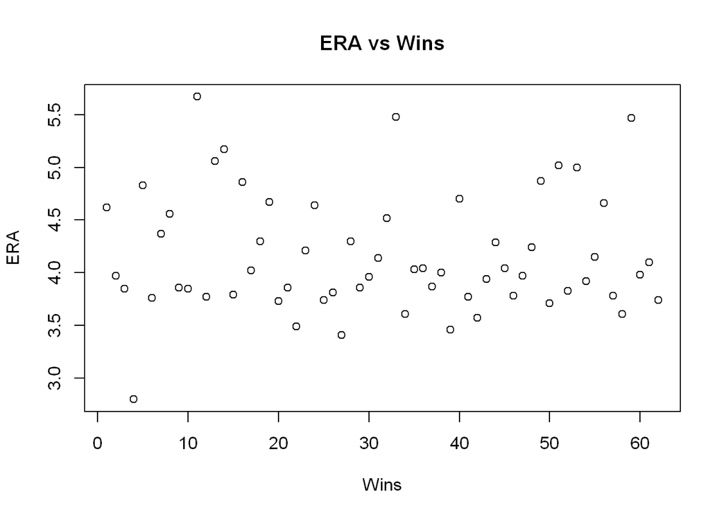

```r
plot(train_data$ERA, train_data$y_var, main = "ERA vs Wins", ylab = "ERA", xlab = "Wins")
```

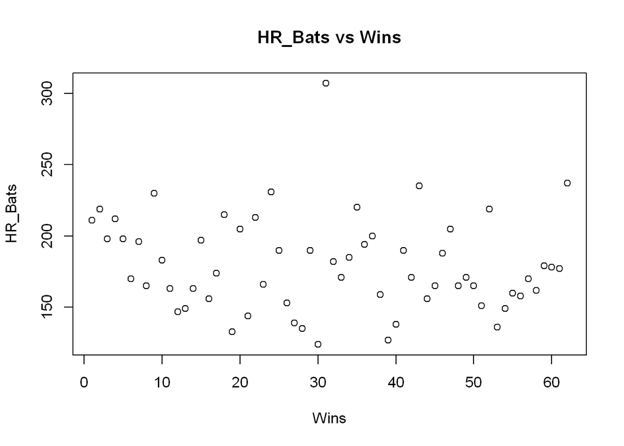

```r
plot(train_data$HR_Bat, train_data$y_var, main = "HR_Bats vs Wins", ylab = "HR_Bats", xlab = "Wins")
```

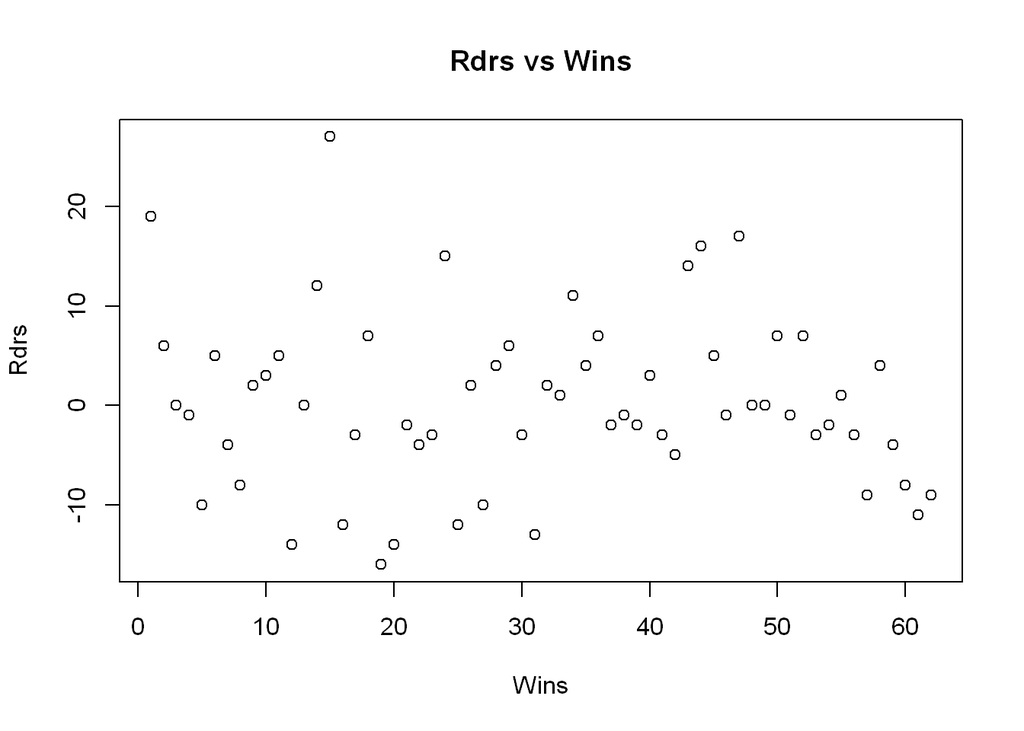

```r
plot(train_data$Rdrs, train_data$y_var, main = "Rdrs vs Wins", ylab = "Rdrs", xlab = "Wins")
```

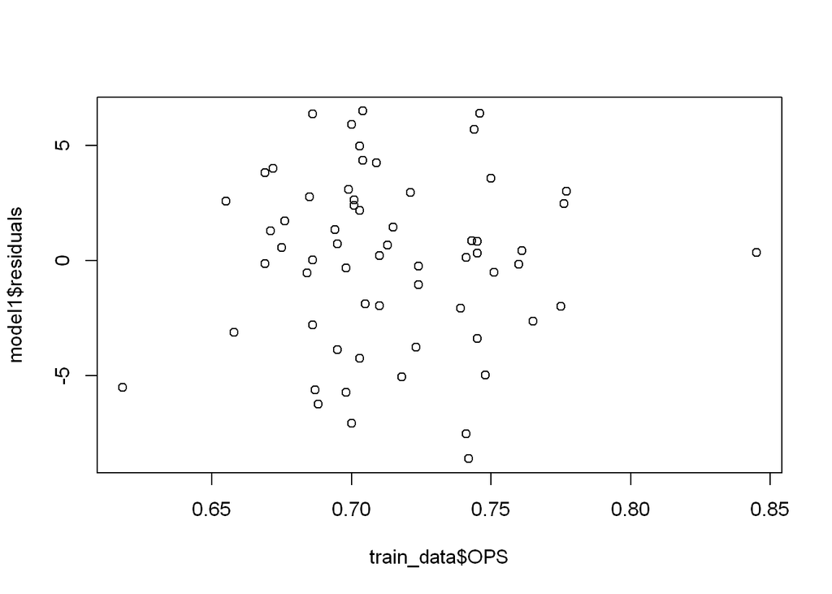

```r
plot(model1$residuals ~ train_data$OPS)
```

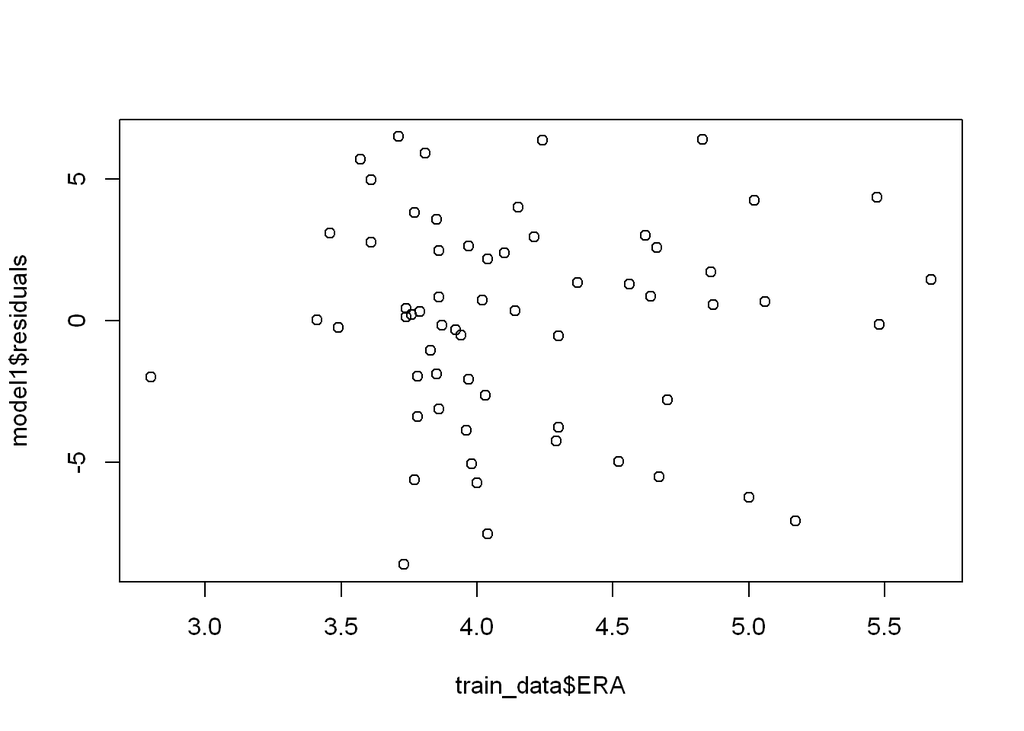

```r
plot(model1$residuals ~ train_data$ERA)
```

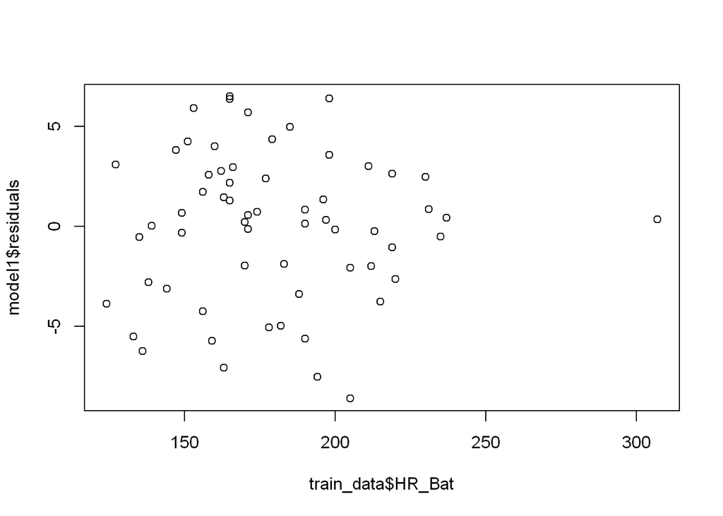

```r
plot(model1$residuals ~ train_data$HR_Bat)
```

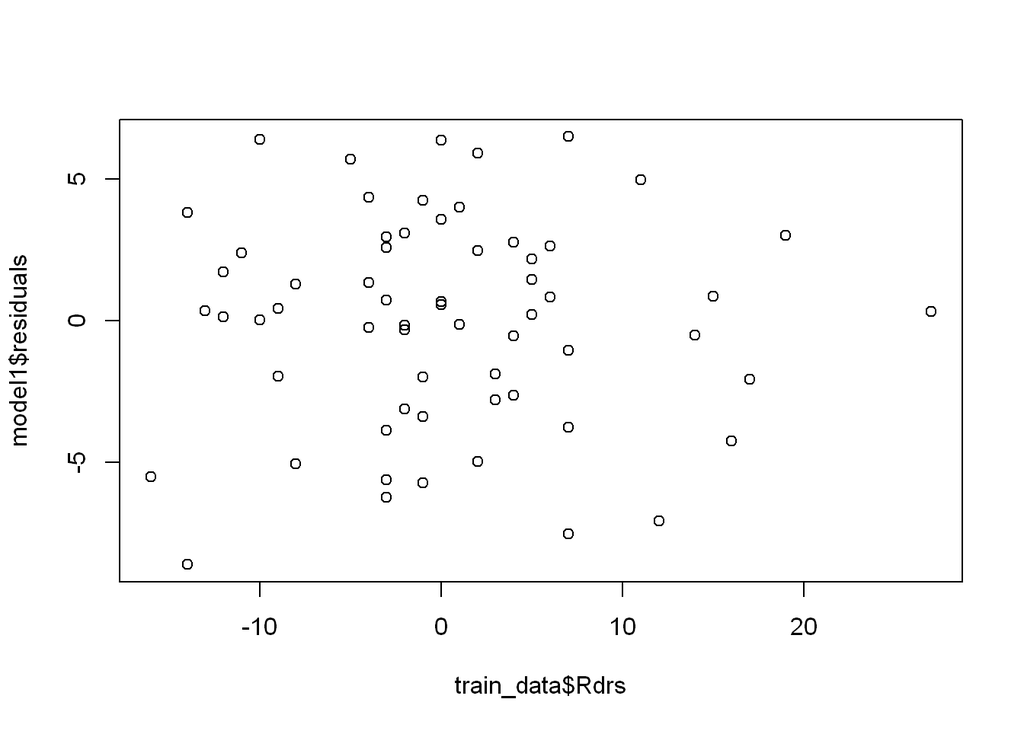

```r
plot(model1$residuals ~ train_data$Rdrs)
```

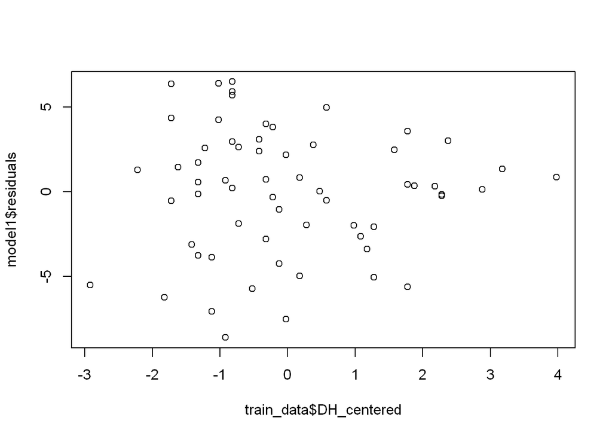

```r
plot(model1$residuals ~ train_data$DH_centered)
```

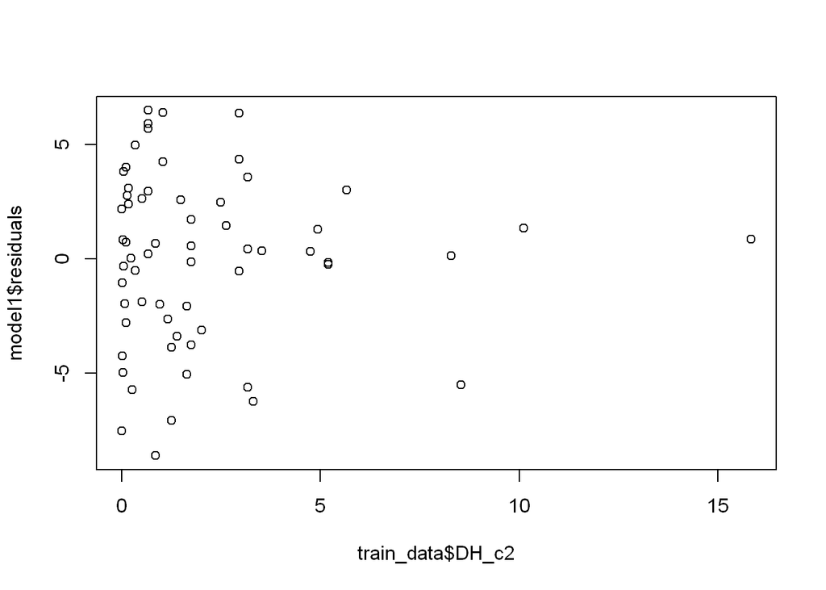

```r
plot(model1$residuals ~ train_data$DH_c2)
```

Y does not require a box-cox transformation. None of the residuals don’t require a transformation fulfill constant variance. The DH_c2 might seem alarming but that is without the centering variable which shows constant variance. None of the predictor variables based off of any of the plots or residual diagnostics seem to require a transformation. Everything seems normal so there is no need for a transformation of Y or any of the predictor variables.

#Step 6

Refined model

```r
refined_model <- lm(W ~ OPS + ERA + HR_Bat + Rdrs + DH_centered + DH_c2, data = train_data)
summary(refined_model)
```

```
##
## Call:
## lm(formula = W ~ OPS + ERA + HR_Bat + Rdrs + DH_centered + DH_c2,
##     data = train_data)
##
## Residuals:
##     Min      1Q  Median      3Q     Max
## -8.5954 -2.4860  0.3339  2.6255  6.4911
##
## Coefficients:
##              Estimate Std. Error t value Pr(>|t|)
## (Intercept) -10.81121   15.20349  -0.711   0.4800
## OPS         222.08315   24.80287   8.954  2.5e-12 ***
## ERA         -14.80939    1.14024 -12.988  < 2e-16 ***
## HR_Bat       -0.03073    0.02649  -1.160   0.2512
## Rdrs          0.08128    0.06079   1.337   0.1867
## DH_centered   0.26782    0.61834   0.433   0.6666
## DH_c2        -0.53849    0.24575  -2.191   0.0327 *
## ---
## Signif. codes:  0 '***' 0.001 '**' 0.01 '*' 0.05 '.' 0.1 ' ' 1
##
## Residual standard error: 3.902 on 55 degrees of freedom
## Multiple R-squared:  0.9255, Adjusted R-squared:  0.9174
## F-statistic: 113.9 on 6 and 55 DF,  p-value: < 2.2e-16
```

```r
vif(refined_model)
```

```
##         OPS         ERA      HR_Bat        Rdrs DH_centered       DH_c2
##    3.375541    1.635608    3.055684    1.116546    3.240590    1.941614
```

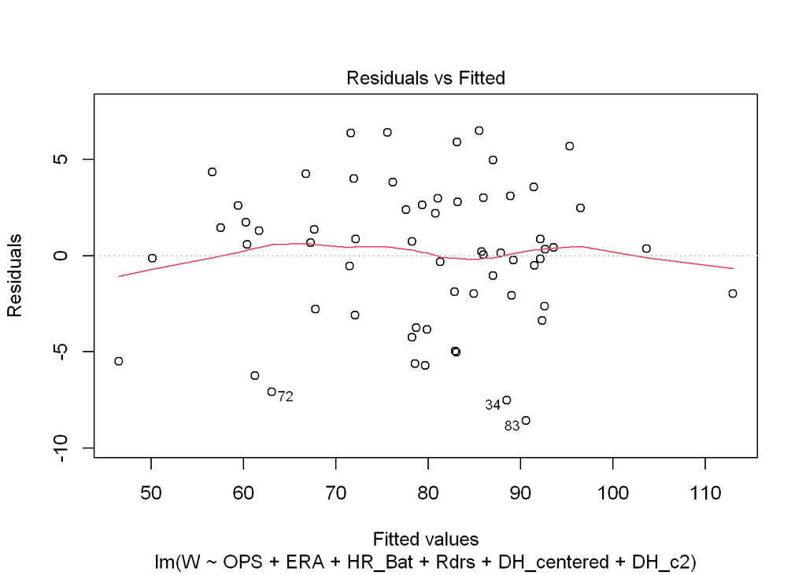

```r
plot(model1, which = 1)
```

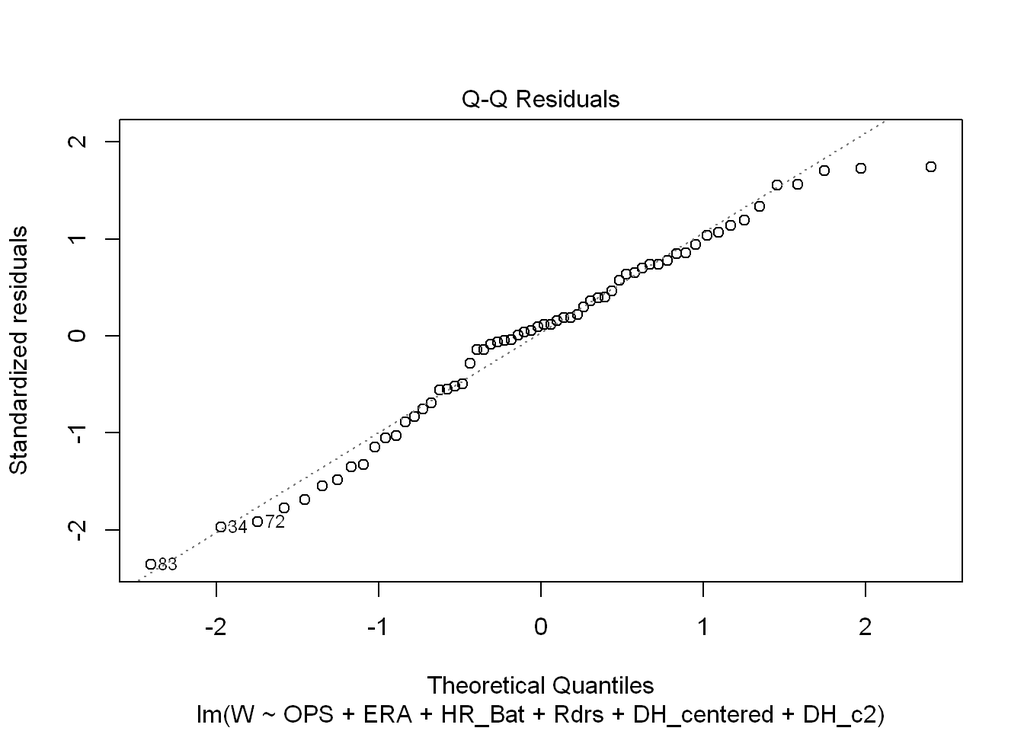

```r
plot(model1, which = 2)
```

```r
hist(residuals(model),
     main = "Histogram of Residuals for Model 1",
     xlab = "Residuals")
```

[output not shown]

```r
#install.packages("lmtest")
library(lmtest)
dwtest(model1)
```

```
##
##  Durbin-Watson test
##
## data:  model1
## DW = 1.8743, p-value = 0.3101
## alternative hypothesis: true autocorrelation is greater than 0
```

#Step 7

```r
DH_mean <- mean(train_data$DH)

test_data$DH_centered <- test_data$DH - DH_mean
test_data$DH_c2 <- test_data$DH_centered^2


pred_test <- predict(refined_model, newdata = test_data)


RMSE <- sqrt(mean((test_data$Y = pred_test)^2))
RMSE
```

```
## [1] 82.81278
```

```r
model <- lm(formula = W ~ OPS + ERA + FIP + HR_Bat + Rdrs, data = train_data)
summary(model)
```

```
##
## Call:
## lm(formula = W ~ OPS + ERA + FIP + HR_Bat + Rdrs, data = train_data)
##
## Residuals:
##     Min      1Q  Median      3Q     Max
## -8.8739 -2.7112  0.3021  2.7023  7.7840
##
## Coefficients:
##              Estimate Std. Error t value Pr(>|t|)
## (Intercept)  -9.71790   15.53797  -0.625   0.5342
## OPS         234.29701   23.58345   9.935 5.79e-14 ***
## ERA         -13.60010    1.99841  -6.805 7.25e-09 ***
## FIP          -3.03004    2.63106  -1.152   0.2544
## HR_Bat       -0.04970    0.02582  -1.924   0.0594 .
## Rdrs          0.08094    0.06171   1.312   0.1950
## ---
## Signif. codes:  0 '***' 0.001 '**' 0.01 '*' 0.05 '.' 0.1 ' ' 1
##
## Residual standard error: 4.033 on 56 degrees of freedom
## Multiple R-squared:  0.919,  Adjusted R-squared:  0.9118
## F-statistic: 127.1 on 5 and 56 DF,  p-value: < 2.2e-16
```

```r
pred_test <- predict(model, newdata = test_data)

RMSE <- sqrt(mean((test_data$Y = pred_test)^2))
RMSE
```

```
## [1] 83.64077
```

```r
mean_W <- mean(train_data$W)
mean_W
```

```
## [1] 79.51613
```

```r
sd_W <- sd(train_data$W)
sd_W
```

```
## [1] 13.57764
```